# Practical Machine Learning Prediction Assignment

Indira Pehlic

## Introduction

Using devices such as Jawbone Up, Nike FuelBand, and Fitbit it is now possible to collect a large amount of data about personal activity relatively inexpensively. The goal of this project is to predict how well a bicep curl was performed using the data from accelerometers on the belt, forearm, arm, and dumbell of 6 participants. Data for this project comes from http://groupware.les.inf.puc-rio.br/har

Six participants performed 10 bicep curls in five different fashions: exactly according to the correct specification (Class A), throwing the elbows to the front (Class B), lifting the dumbbell only halfway (Class C), lowering the dumbbell only halfway (Class D) and throwing the hips to the front (Class E).

## Data Processing

The section below includes downloading data and creating training/testing partitions.

```r
#Setting seed for reproducibility
set.seed(22)

#Download the data
#download.file("https://d396qusza40orc.cloudfront.net/predmachlearn/pml-training.csv", destfile = "training.csv")

#download.file("https://d396qusza40orc.cloudfront.net/predmachlearn/pml-testing.csv", destfile = "testing.csv")

#Full data for partitioning
data <- read.csv("training.csv", stringsAsFactors=TRUE)

#20 Cases for Validation
validation <- read.csv("testing.csv", stringsAsFactors=TRUE)

dim(data)
```

```
## [1] 19622   160
```

```r
#Splitting the data for test/train partitions
set.seed(127)
training_sample <- createDataPartition(y=data$classe, p=0.7, list=FALSE)
training <- data[training_sample, ]
testing <- data[-training_sample, ]
dim(training)
```

```
## [1] 13737   160
```

```r
dim(testing)
```

```
## [1] 5885  160
```

Both datasets have 160 variables. The variables have quite a few of NA, that are removed. The Near Zero variance (NZV) variables and the ID variables are also removed.

```r
#Remove variables with Nearly Zero Variance
NZV <- nearZeroVar(training)
training <- training[, -NZV]
testing  <- testing[, -NZV]
dim(training)
```

```
## [1] 13737   105
```

```r
dim(testing)
```

```
## [1] 5885  105
```

```r
#Remove variables that are NA
allNA    <- sapply(training, function(x) mean(is.na(x))) > 0.95
training <- training[, allNA==FALSE]
testing  <- testing[, allNA==FALSE]
dim(training)
```

```
## [1] 13737    59
```

```r
dim(testing)
```

```
## [1] 5885   59
```

```r
#Remove identification variables
training <- training[, -(1:5)]
testing <- testing[, -(1:5)]
dim(training)
```

```
## [1] 13737    54
```

```r
dim(testing)
```

```
## [1] 5885   54
```

The corrplot graph indicates correlated variables which are shown in dark colours.

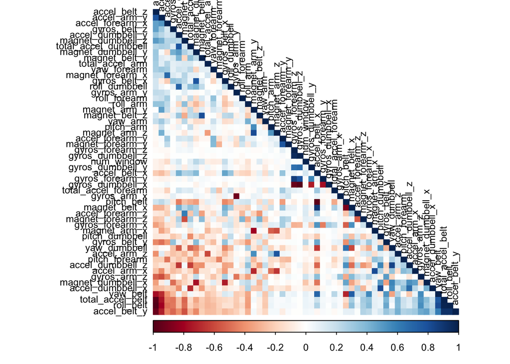

```r
cor_mat <- cor(training[, -54])
corrplot(cor_mat, order = "FPC", method = "color", type = "lower",
         tl.cex = 0.8, tl.col = rgb(0, 0, 0))
```

## Model Fitting

The following modeling methods will be applied to predict the outcome: 1. Decision Tree 2. Random Forests 3. Generalized Boosted Model

### Decesion Tree Modelling

```r
set.seed(12345)
model_dt <- rpart(classe ~ ., data=training, method="class")

#Predicting on test dataset
predict_dt <- predict(model_dt, testing, type = "class")
cmDT <- confusionMatrix(predict_dt, testing$classe)
cmDT
```

```
## Confusion Matrix and Statistics
##
##           Reference
## Prediction    A    B    C    D    E
##          A 1536  279   62  106   57
##          B   43  619   29   30   19
##          C    7   62  820  133   59
##          D   70  126   55  595  138
##          E   18   53   60  100  809
##
## Overall Statistics
##
##                Accuracy : 0.7441
##                  95% CI : (0.7327, 0.7552)
##     No Information Rate : 0.2845
##     P-Value [Acc > NIR] : < 2.2e-16
##
##                   Kappa : 0.6741
##
##  Mcnemar's Test P-Value : < 2.2e-16
##
## Statistics by Class:
##
##                      Class: A Class: B Class: C Class: D Class: E
## Sensitivity            0.9176   0.5435   0.7992   0.6172   0.7477
## Specificity            0.8803   0.9745   0.9463   0.9210   0.9519
## Pos Pred Value         0.7529   0.8365   0.7586   0.6047   0.7779
## Neg Pred Value         0.9641   0.8989   0.9571   0.9247   0.9437
## Prevalence             0.2845   0.1935   0.1743   0.1638   0.1839
## Detection Rate         0.2610   0.1052   0.1393   0.1011   0.1375
## Detection Prevalence   0.3466   0.1257   0.1837   0.1672   0.1767
## Balanced Accuracy      0.8989   0.7590   0.8728   0.7691   0.8498
```

### Random Forest Modelling

```r
control_rf <- trainControl(method="cv", number=3, verboseIter=TRUE)
model_rf <- train(classe ~ ., data=training, method="rf", trControl=control_rf, importance = TRUE)
model_rf$finalModel
```

```
##
## Call:
##  randomForest(x = x, y = y, mtry = param$mtry, importance = TRUE)
##                Type of random forest: classification
##                      Number of trees: 500
## No. of variables tried at each split: 27
##
##         OOB estimate of  error rate: 0.25%
## Confusion matrix:
##      A    B    C    D    E  class.error
## A 3905    1    0    0    0 0.0002560164
## B   10 2646    2    0    0 0.0045146727
## C    0    5 2390    1    0 0.0025041736
## D    0    0   10 2242    0 0.0044404973
## E    0    0    0    5 2520 0.0019801980
```

```r
#Predicting on test dataset
predict_rf <- predict(model_rf, newdata=testing)
cmRF <- confusionMatrix(predict_rf, testing$classe)
cmRF
```

```
## Confusion Matrix and Statistics
##
##           Reference
## Prediction    A    B    C    D    E
##          A 1673    0    0    0    0
##          B    1 1139    0    0    2
##          C    0    0 1026    3    0
##          D    0    0    0  961    1
##          E    0    0    0    0 1079
##
## Overall Statistics
##
##                Accuracy : 0.9988
##                  95% CI : (0.9976, 0.9995)
##     No Information Rate : 0.2845
##     P-Value [Acc > NIR] : < 2.2e-16
##
##                   Kappa : 0.9985
##
##  Mcnemar's Test P-Value : NA
##
## Statistics by Class:
##
##                      Class: A Class: B Class: C Class: D Class: E
## Sensitivity            0.9994   1.0000   1.0000   0.9969   0.9972
## Specificity            1.0000   0.9994   0.9994   0.9998   1.0000
## Pos Pred Value         1.0000   0.9974   0.9971   0.9990   1.0000
## Neg Pred Value         0.9998   1.0000   1.0000   0.9994   0.9994
## Prevalence             0.2845   0.1935   0.1743   0.1638   0.1839
## Detection Rate         0.2843   0.1935   0.1743   0.1633   0.1833
## Detection Prevalence   0.2843   0.1941   0.1749   0.1635   0.1833
## Balanced Accuracy      0.9997   0.9997   0.9997   0.9983   0.9986
```

### Generalized Boosted Modelling

```r
set.seed(12345)
control_gbm<- trainControl(method = "repeatedcv", number = 5, repeats = 1)
model_gbm  <- train(classe ~ ., data=training, method = "gbm",
                    trControl = control_gbm, verbose = FALSE)
model_gbm$finalModel
```

```
## A gradient boosted model with multinomial loss function.
## 150 iterations were performed.
## There were 53 predictors of which 53 had non-zero influence.
```

```r
#Predicting on test dataset
predict_gbm <- predict(model_gbm, newdata=testing)
cmGBM <- confusionMatrix(predict_gbm, testing$classe)
cmGBM
```

```
## Confusion Matrix and Statistics
##
##           Reference
## Prediction    A    B    C    D    E
##          A 1666    7    0    0    0
##          B    8 1121    4    3    5
##          C    0   11 1020    8    0
##          D    0    0    1  951   10
##          E    0    0    1    2 1067
##
## Overall Statistics
##
##                Accuracy : 0.9898
##                  95% CI : (0.9869, 0.9922)
##     No Information Rate : 0.2845
##     P-Value [Acc > NIR] : < 2.2e-16
##
##                   Kappa : 0.9871
##
##  Mcnemar's Test P-Value : NA
##
## Statistics by Class:
##
##                      Class: A Class: B Class: C Class: D Class: E
## Sensitivity            0.9952   0.9842   0.9942   0.9865   0.9861
## Specificity            0.9983   0.9958   0.9961   0.9978   0.9994
## Pos Pred Value         0.9958   0.9825   0.9817   0.9886   0.9972
## Neg Pred Value         0.9981   0.9962   0.9988   0.9974   0.9969
## Prevalence             0.2845   0.1935   0.1743   0.1638   0.1839
## Detection Rate         0.2831   0.1905   0.1733   0.1616   0.1813
## Detection Prevalence   0.2843   0.1939   0.1766   0.1635   0.1818
## Balanced Accuracy      0.9968   0.9900   0.9951   0.9921   0.9928
```

By comparing the accuracy rate values of the three models, the random forest model performed the best overall, and will be used to predict the validation set.

```
##   Model  Accuracy
## 1    RF 0.9988105
## 2   GBM 0.9898046
## 3    DT 0.7440952
```

## Prediction

The random forest model is used to predict classe variable for each of the 20 observations in the validation data sample (‘pml-testing.csv’).

```r
pred_Val <- predict(model_rf, newdata=validation)
print(pred_Val)
```

```
##  [1] B A B A A E D B A A B C B A E E A B B B
## Levels: A B C D E
```